# Introduction to Open Data Science

### Figure 9.3 Scatterplot matrix of repeated measures in bprs data

Let’s now we see the scatter plot below where we plot the repeated measures of bprs. From the plot, we see evidence that the repeated measures are not independent of one another.

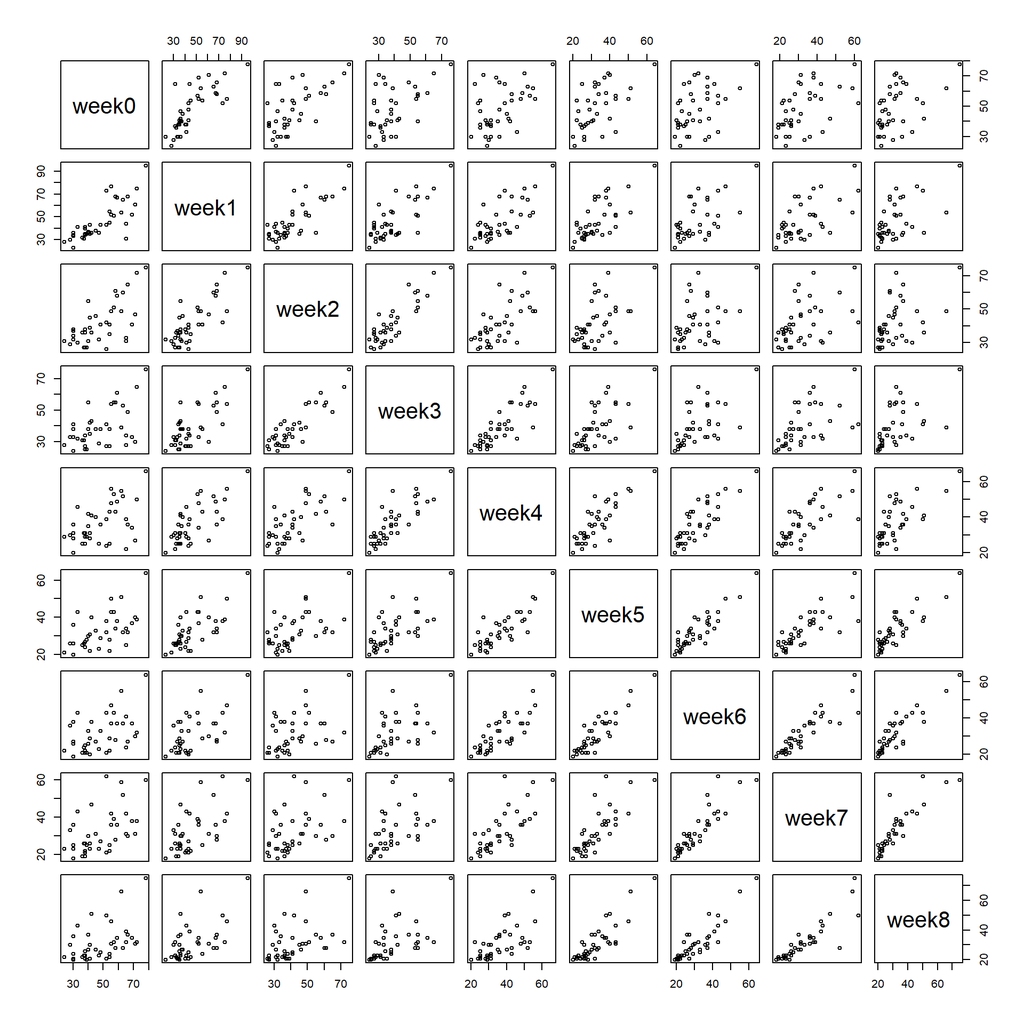

```r
pairs(BPRS[, 3:11], cex = 0.7)
```

### Table 9.4 Fitting Random Intercept Model, with week and treatment as Explanatory Variables, to BPRS Data

Now, we model using Linear Mixed-Effects Models estimated using maximum likelihood, with the R package “lme4”. Basically, we model the following:

$y_{ij}=(\beta_0+u_i)+\beta_1t_j+\beta_2D_{i1}+\varepsilon_{ij}$

where $y_{ij}$ represents the $i$th observation at time $j$, $u_i$ is the random effect specific to the $i$th subject normally distributed with zero mean variance $\sigma_u^2$. $\varepsilon_{ij}$ is the error term normally distributed with zero mean and variance $\sigma^2$. $D_{1i}$ is the dummy variable used to code the treatment group 2.

```r
library("lme4")
```

```r
BPRS_ref <- lmer(bprs ~ week + treatment + (1 | subject), data = BPRSL, REML = FALSE)
summary(BPRS_ref)
```

```
## Linear mixed model fit by maximum likelihood  ['lmerMod']
## Formula: bprs ~ week + treatment + (1 | subject)
##    Data: BPRSL
##
##      AIC      BIC   logLik deviance df.resid
##   2748.7   2768.1  -1369.4   2738.7      355
##
## Scaled residuals:
##     Min      1Q  Median      3Q     Max
## -3.0481 -0.6749 -0.1361  0.4813  3.4855
##
## Random effects:
##  Groups   Name        Variance Std.Dev.
##  subject  (Intercept)  47.41    6.885
##  Residual             104.21   10.208
## Number of obs: 360, groups:  subject, 20
##
## Fixed effects:
##             Estimate Std. Error t value
## (Intercept)  46.4539     1.9090  24.334
## week         -2.2704     0.2084 -10.896
## treatment2    0.5722     1.0761   0.532
##
## Correlation of Fixed Effects:
##            (Intr) week
## week       -0.437
## treatment2 -0.282  0.000
```

```r
# display the actual coefficients
equatiomatic::extract_eq(BPRS_ref, use_coefs = TRUE)
```

$$\begin{aligned}
\operatorname{\widehat{bprs}}_{i} &\sim N \left(46.45_{\alpha_{j[i]}} - 2.27_{\beta_{1}}(\operatorname{week}) + 0.57_{\beta_{2}}(\operatorname{treatment}_{\operatorname{2}}), \sigma^2 \right) \\
\alpha_{j} &\sim N \left(0, 6.89 \right)
\text{, for subject j = 1,} \dots \text{,J}
\end{aligned}$$

From the results, we have similar results to the previous (the simple OLS linear regression) where the intercept and time variable (‘week’) are significant, but not the treatment 2. We also get similar estimates of coefficients, but with smaller standard errors on the time variable (‘week’) and the group treatment variable (‘treatment2’). In addition, we have confirmation of negative correlation of ‘week’ with response variable and the intercept.

### Table 9.5 Fitting the Random Intercept and Slope Model, with week and treatment as Explanatory Variables, to BPRS Data

Next, we fit the random intercept and random slope model to the bprs data. The model has the form of the following:

$y_{ij}=(\beta_0+u_i)+(\beta_1+v_i)t_j+\beta_2D_{i1}+\varepsilon_{ij}$

where the extra term from the random intercept model is the random effect $v_i$ that allows the linear regression fits for each individual to differ in slope. These random effects are assumed normally distributed with zero mean and variance $\sigma_v^2$ and are allowed to be correlated with the $u_i$ random intercept effects.

```r
BPRS_ref1 <- lmer(bprs ~ week + treatment + (week | subject), data = BPRSL, REML = FALSE)
summary(BPRS_ref1)
```

```
## Linear mixed model fit by maximum likelihood  ['lmerMod']
## Formula: bprs ~ week + treatment + (week | subject)
##    Data: BPRSL
##
##      AIC      BIC   logLik deviance df.resid
##   2745.4   2772.6  -1365.7   2731.4      353
##
## Scaled residuals:
##     Min      1Q  Median      3Q     Max
## -2.8919 -0.6194 -0.0691  0.5531  3.7976
##
## Random effects:
##  Groups   Name        Variance Std.Dev. Corr
##  subject  (Intercept) 64.8222  8.0512
##           week         0.9609  0.9802   -0.51
##  Residual             97.4305  9.8707
## Number of obs: 360, groups:  subject, 20
##
## Fixed effects:
##             Estimate Std. Error t value
## (Intercept)  46.4539     2.1052  22.066
## week         -2.2704     0.2977  -7.626
## treatment2    0.5722     1.0405   0.550
##
## Correlation of Fixed Effects:
##            (Intr) week
## week       -0.582
## treatment2 -0.247  0.000
```

```r
# display the actual coefficients
equatiomatic::extract_eq(BPRS_ref1, use_coefs = TRUE)
```

$$\begin{aligned}
\operatorname{\widehat{bprs}}_{i} &\sim N \left(46.45_{\alpha_{j[i]}} - 2.27_{\beta_{1j[i]}}(\operatorname{week}) + 0.57_{\beta_{2}}(\operatorname{treatment}_{\operatorname{2}}), \sigma^2 \right) \\
\left(
\begin{array}{c}
\begin{aligned}
&\alpha_{j} \\
&\beta_{1j}
\end{aligned}
\end{array}
\right)
&\sim N \left(
\left(
\begin{array}{c}
\begin{aligned}
&0 \\
&0
\end{aligned}
\end{array}
\right)
,
\left(
\begin{array}{cc}
8.05 & -0.51 \\
-0.51 & 0.98
\end{array}
\right)
\right)
\text{, for subject j = 1,} \dots \text{,J}
\end{aligned}$$

```r
# anova
anova(BPRS_ref1, BPRS_ref)
```

```
## Data: BPRSL
## Models:
## BPRS_ref: bprs ~ week + treatment + (1 | subject)
## BPRS_ref1: bprs ~ week + treatment + (week | subject)
##           npar    AIC    BIC  logLik deviance  Chisq Df Pr(>Chisq)
## BPRS_ref     5 2748.7 2768.1 -1369.4   2738.7
## BPRS_ref1    7 2745.4 2772.6 -1365.7   2731.4 7.2721  2    0.02636 *
## ---
## Signif. codes:  0 '***' 0.001 '**' 0.01 '*' 0.05 '.' 0.1 ' ' 1
```

### Table 9.6 Fitting the Random Intercept and Slope Model that Allows for a treatment × week Interaction to BPRS Data

Finally, we fit a random intercept and slope model that allows for a group $\times$ time interaction. This model takes the following form:

$y_{ij}=(\beta_0+u_i)+(\beta_1+v_i)t_j+\beta_2D_{i1}+\beta_3(D_{i1}\times t_j)+\varepsilon_{ij}$

where $\beta_3(D_{i1}\times t_j)$ is the additional term compared to the previous model.

```r
BPRS_ref2 <- lmer(bprs ~ week * treatment + (week | subject), data = BPRSL, REML = FALSE)
summary(BPRS_ref2)
```

```
## Linear mixed model fit by maximum likelihood  ['lmerMod']
## Formula: bprs ~ week * treatment + (week | subject)
##    Data: BPRSL
##
##      AIC      BIC   logLik deviance df.resid
##   2744.3   2775.4  -1364.1   2728.3      352
##
## Scaled residuals:
##     Min      1Q  Median      3Q     Max
## -3.0512 -0.6271 -0.0768  0.5288  3.9260
##
## Random effects:
##  Groups   Name        Variance Std.Dev. Corr
##  subject  (Intercept) 64.9964  8.0620
##           week         0.9687  0.9842   -0.51
##  Residual             96.4707  9.8220
## Number of obs: 360, groups:  subject, 20
##
## Fixed effects:
##                 Estimate Std. Error t value
## (Intercept)      47.8856     2.2521  21.262
## week             -2.6283     0.3589  -7.323
## treatment2       -2.2911     1.9090  -1.200
## week:treatment2   0.7158     0.4010   1.785
##
## Correlation of Fixed Effects:
##             (Intr) week   trtmn2
## week        -0.650
## treatment2  -0.424  0.469
## wek:trtmnt2  0.356 -0.559 -0.840
```

```r
# display the actual coefficients
equatiomatic::extract_eq(BPRS_ref2, use_coefs = TRUE)
```

$$\begin{aligned}
\operatorname{\widehat{bprs}}_{i} &\sim N \left(\mu, \sigma^2 \right) \\
\mu &=47.89_{\alpha_{j[i]}} - 2.63_{\beta_{1j[i]}}(\operatorname{week}) - 2.29_{\beta_{2}}(\operatorname{treatment}_{\operatorname{2}}) + 0.72_{\beta_{3}}(\operatorname{treatment}_{\operatorname{2}} \times \operatorname{week}) \\
\left(
\begin{array}{c}
\begin{aligned}
&\alpha_{j} \\
&\beta_{1j}
\end{aligned}
\end{array}
\right)
&\sim N \left(
\left(
\begin{array}{c}
\begin{aligned}
&0 \\
&0
\end{aligned}
\end{array}
\right)
,
\left(
\begin{array}{cc}
8.06 & -0.51 \\
-0.51 & 0.98
\end{array}
\right)
\right)
\text{, for subject j = 1,} \dots \text{,J}
\end{aligned}$$

```r
# anova
anova(BPRS_ref1, BPRS_ref2)
```

```
## Data: BPRSL
## Models:
## BPRS_ref1: bprs ~ week + treatment + (week | subject)
## BPRS_ref2: bprs ~ week * treatment + (week | subject)
##           npar    AIC    BIC  logLik deviance  Chisq Df Pr(>Chisq)
## BPRS_ref1    7 2745.4 2772.6 -1365.7   2731.4
## BPRS_ref2    8 2744.3 2775.4 -1364.1   2728.3 3.1712  1    0.07495 .
## ---
## Signif. codes:  0 '***' 0.001 '**' 0.01 '*' 0.05 '.' 0.1 ' ' 1
```